# Minería de datos: PRA1 - Selección y preparación de un juego de datos

### Autor: **Gerson Villalba Arana**

### Diciembre 2021

Este documento contiene la PRA1 y a continuación la PRA2 de la asignatura "Minería de Datos", ya que ésta parte de la solución de la primera.

## Elección del conjunto de datos

En la presenta práctica se va a realizar los procesos de selección, limpieza, preparación y visualización de datos para posteriormente, en la segunda parte de la práctica (PRA2), entrenar modelos para poder obtener información útil para el área en cuestión que estemos tratando.

El tema elegido para la realización de la práctica es el de **optimización de procesos de reserva de noches de hotel** en web especializadas. Como base para el trabajo, se parte de un dataset con información histórica sobre reservas de hoteles en dos tipos de hoteles distintos en Portugal. El dataset se encuentra disponible públicamente en el repositorio de Kaggle: https://www.kaggle.com/insatanic/hotel-booking-data-analysis.

En base a la información proporcionada por dicho dataset, se propone un proyecto de minería de datos de **clasificación**, teniendo como objetivo **predecir si una habitación de hotel reservada va o no a ser cancelada** por parte del cliente hasta que llegue la fecha de reserva. Derivada de esta clasificación, nos podríamos plantear un segundo objetivo que sería, ya no predecir si una reserva va a ser cancelada, sino obtener una probabilidad de que esto ocurra. Por lo tanto, el proyecto resultará en un clasificador binario, donde las dos clases serán Si/No (va a ser cancelada la reserva). Sin ambargo, pomo podremos ver, de un clasificador binario podemos no sólamente podemos obtener la categoría o clase como salida, sino también la probabilidad de que se de cada una de las clases, que será lo que utilizaremos para determinar la probabilidad de que una reserva sea cancelada. Esta información puede ser valiosísima tanto para hoteles como para webs de reserva:

- Se tiene una visión más realista de la ocupación real que va a tener un hotel en base a las reservas actuales, lo cual puede ayudar a optimizar recursos y gastos: ¿es necesario tener productos perecederos para 500 comensales en el buffet, o es suficiente contar para 400? ¿Cuántas habitaciones van a tener que ser limpiadas?
- Se puede sobre-reservar el hotel (*overbooking*) en cierta medida, teniendo en cuenta que algunas de las reservas actuales se van a acabar cancelando. De esta manera se optimiza la ocupación del hotel y por lo tanto los ingresos.
- Se puede conocer el perfil de cliente que es más propenso a cancelar. De esta forma, podemos dirigir nuestro márketing al público más interesante desde el punto de vista de negocio: aquellos con menor probabilidad de cancelar una reserva.
- Se pueden buscar estrategias para evitar la cancelación de reservas sobre aquellas que detectamos con más probabilidades de ser canceladas. Podemos ofrecer incentivos para los huespedes, como cambiarle gratuitamente a una habitación superior, ofrecerles descuentos en actividades del lugar, etc.

Toda esta información puede repercutir en miles de euros en aumento de ingresos y optimización de costes en un sólo hotel, en millones en una web de reserva con miles de hoteles que pierde una comisión cada vez que un cliente cancela una reserva.

Por supuesto, el alcance de este trabajo es limitado y trataremos sólo con este dataset, pero podría ser ampliado en gran manera, añadiendo nueva información, tanto en forma de nuevas muestras (más hoteles y de otros países, para tener un modelo mejor entrenado) como de nuevas características que pudiese mejorar la capacidad predictora del modelo.

## Exploración del conjunto de datos

En primer lugar, tendremos que importar los datos disponibles, que consiste en un .csv.

```python
import pandas as pd
import numpy as np
import seaborn as sns
import matplotlib.pyplot as plt

df = pd.read_csv('hotel_bookings.csv')
df.head()
```

|  | hotel | is_canceled | lead_time | arrival_date_year | arrival_date_month | arrival_date_week_number | arrival_date_day_of_month | stays_in_weekend_nights | stays_in_week_nights | adults | ... | deposit_type | agent | company | days_in_waiting_list | customer_type | adr | required_car_parking_spaces | total_of_special_requests | reservation_status | reservation_status_date |
| --- | --- | --- | --- | --- | --- | --- | --- | --- | --- | --- | --- | --- | --- | --- | --- | --- | --- | --- | --- | --- | --- |
| 0 | Resort Hotel | 0 | 342 | 2015 | July | 27 | 1 | 0 | 0 | 2 | ... | No Deposit | NaN | NaN | 0 | Transient | 0.0 | 0 | 0 | Check-Out | 2015-07-01 |
| 1 | Resort Hotel | 0 | 737 | 2015 | July | 27 | 1 | 0 | 0 | 2 | ... | No Deposit | NaN | NaN | 0 | Transient | 0.0 | 0 | 0 | Check-Out | 2015-07-01 |
| 2 | Resort Hotel | 0 | 7 | 2015 | July | 27 | 1 | 0 | 1 | 1 | ... | No Deposit | NaN | NaN | 0 | Transient | 75.0 | 0 | 0 | Check-Out | 2015-07-02 |
| 3 | Resort Hotel | 0 | 13 | 2015 | July | 27 | 1 | 0 | 1 | 1 | ... | No Deposit | 304.0 | NaN | 0 | Transient | 75.0 | 0 | 0 | Check-Out | 2015-07-02 |
| 4 | Resort Hotel | 0 | 14 | 2015 | July | 27 | 1 | 0 | 2 | 2 | ... | No Deposit | 240.0 | NaN | 0 | Transient | 98.0 | 0 | 1 | Check-Out | 2015-07-03 |

5 rows × 32 columns

```python
df.info()
```

```
<class 'pandas.core.frame.DataFrame'>
RangeIndex: 119390 entries, 0 to 119389
Data columns (total 32 columns):
 #   Column                          Non-Null Count   Dtype
---  ------                          --------------   -----
 0   hotel                           119390 non-null  object
 1   is_canceled                     119390 non-null  int64
 2   lead_time                       119390 non-null  int64
 3   arrival_date_year               119390 non-null  int64
 4   arrival_date_month              119390 non-null  object
 5   arrival_date_week_number        119390 non-null  int64
 6   arrival_date_day_of_month       119390 non-null  int64
 7   stays_in_weekend_nights         119390 non-null  int64
 8   stays_in_week_nights            119390 non-null  int64
 9   adults                          119390 non-null  int64
```

[output cut: 24 more lines]

Podemos observar que el conjunto de datos tiene 119390 filas o muestras y 32 columnas o atributos. Por lo tanto, el dataset es bastante grande.

Realizamos a continuación un análisis de los atributos que tenemos:

## Limpieza de datos

Realizamos un análisis de los valores nulos que tenemos en el dataset.

```python
df.isna().sum()
```

```
hotel                                  0
is_canceled                            0
lead_time                              0
arrival_date_year                      0
arrival_date_month                     0
arrival_date_week_number               0
arrival_date_day_of_month              0
stays_in_weekend_nights                0
stays_in_week_nights                   0
adults                                 0
children                               4
babies                                 0
meal                                   0
country                              488
market_segment                         0
distribution_channel                   0
is_repeated_guest                      0
previous_cancellations                 0
previous_bookings_not_canceled         0
reserved_room_type                     0
assigned_room_type                     0
booking_changes                        0
deposit_type                           0
agent                              16340
company                           112593
days_in_waiting_list                   0
customer_type                          0
adr                                    0
required_car_parking_spaces            0
total_of_special_requests              0
reservation_status                     0
reservation_status_date                0
dtype: int64
```

Vemos como tenemos valores nulos en cuatro de los campos:

- children: Sólo tenemos 4 valores nulos, eliminaremos esos registros.
- country: Tenemos muy pocos valores nulos en relación al número total de registros, los eliminamos.
- agent: Tenemos una cantidad no despreciable de valores nulos y, además, como esta característica no pensamos que pueda tener gran capacidad predictiva sobre si el cliente va a cancelar la reserva, la eliminamos.
- company: Tenemos todavía más valores nulos, pero nos pasa lo mismo que en el caso anterior, así que eliminamos la columna.

```python
df.drop(['agent', 'company'], axis=1, inplace=True)
df.dropna(inplace=True)
df.info()
```

```
<class 'pandas.core.frame.DataFrame'>
Int64Index: 118898 entries, 0 to 119389
Data columns (total 30 columns):
 #   Column                          Non-Null Count   Dtype
---  ------                          --------------   -----
 0   hotel                           118898 non-null  object
 1   is_canceled                     118898 non-null  int64
 2   lead_time                       118898 non-null  int64
 3   arrival_date_year               118898 non-null  int64
 4   arrival_date_month              118898 non-null  object
 5   arrival_date_week_number        118898 non-null  int64
 6   arrival_date_day_of_month       118898 non-null  int64
 7   stays_in_weekend_nights         118898 non-null  int64
 8   stays_in_week_nights            118898 non-null  int64
 9   adults                          118898 non-null  int64
```

[output cut: 22 more lines]

## Selección y preparación de datos

Como hemos definido en la introducción, vamos a realizar un modelo que nos permita predecir la cancelación de una reserva de hotel, pero nos vamos a centrar en hacerlo en el momento en que la reserva es confirmada por el hotel. Esto quiere decir que habrá información que no tendremos disponible en ese momento y con la que sí tenemos en el dataset. El caso más llamativo es el de estado de la reserva (*reservation_status*): esta variable muestra el estado de la reserva, y está como es lógico altamente correlada con la que indica si una reserva es finalmente cancelada o no; si el estado de la reserva es "cancelado", la predicción será perfecta o casi perfecta (asumiendo que pueda hacer algún error y finalmente alguna reserva en estado cancelado pueda reactivarse) si tenemos como entrada al modelo predictor esta variable. Pero es evidente que no conocemos el estado de esta variable en el momento de reallizar la reserva, o el menos no tendremos nunca en ella el estado *cancelada*. Este es un claro ejemplo de *data leakage*, con el que hay que tener especial cuidado para no acabar con un modelo cuyo rendimiento en un entorno real sea mucho peor que el varidado en la creación del modelo.

Como nos centraremos en hacer una predicción en la confirmación de la reserva, hay otros datos que, sin ser propiamente *data leakage* no disponemos de ellos inicialmente. Es el caso, por ejemplo, de el número de veces que se ha modificado la reserva. Lógicamnete este dato no lo tenemos en el momento inicial, si bien es cierto que podría utilizarse para añadirlo al modelo conforme estos eventos ocurren y actualizar la predicción, ya que es de esperar que mejorase la capacidad predictiva: un cliente que ha modificado su reserva 5 veces, es muy probable que acabe cancelándola.

Además, hay campos que podemos pensar que no nos aportan información predictiva útil. Es el caso del identificador de agente o compañía que realiza la reserva, o el número de días que la reserva ha tardado en ser confirmada.

Teniendo en cuenta todo esto, eliminamos los campos que no nos interesan:

- booking_changes
- agent (ya eliminado)
- company (ya eliminado)
- days_in waiting_list
- reservation_status
- reservation_status_date

```python
drop_col = ['booking_changes',
           'reservation_status',
           'reservation_status_date',
           'days_in_waiting_list']

df.drop(drop_col, axis=1, inplace=True)
```

Tenemos tres campos que nos definen la fecha de reserva: arrival_date_year, arrival_date_month, arrival_date_day_of_month. Uniremos estas tres columnas en una sóla que defina la fecha de reserva. De esta manera, reducimos el número de atributos y podemos trabajar de forma más cómoda con fechas. Tenemos además una cuarta variable redundante, arrival_date_week_number, que indica la semana del año de la reserva, por lo que la eliminamos.

```python
df['arrival_date'] = df['arrival_date_day_of_month'].astype(str) + '-' \
                    + df['arrival_date_month'] + '-' \
                    + df['arrival_date_year'].astype(str)
df['arrival_date'] = pd.to_datetime(df['arrival_date'], format='%d-%B-%Y')

df.drop(['arrival_date_year', 'arrival_date_month', 'arrival_date_day_of_month', 'arrival_date_week_number'], axis=1, inplace=True)
df.info()
```

```
<class 'pandas.core.frame.DataFrame'>
Int64Index: 118898 entries, 0 to 119389
Data columns (total 23 columns):
 #   Column                          Non-Null Count   Dtype
---  ------                          --------------   -----
 0   hotel                           118898 non-null  object
 1   is_canceled                     118898 non-null  int64
 2   lead_time                       118898 non-null  int64
 3   stays_in_weekend_nights         118898 non-null  int64
 4   stays_in_week_nights            118898 non-null  int64
 5   adults                          118898 non-null  int64
 6   children                        118898 non-null  float64
 7   babies                          118898 non-null  int64
 8   meal                            118898 non-null  object
 9   country                         118898 non-null  object
 10  market_segment                  118898 non-null  object
 11  distribution_channel            118898 non-null  object
 12  is_repeated_guest               118898 non-null  int64
 13  previous_cancellations          118898 non-null  int64
 14  previous_bookings_not_canceled  118898 non-null  int64
 15  reserved_room_type              118898 non-null  object
 16  assigned_room_type              118898 non-null  object
 17  deposit_type                    118898 non-null  object
 18  customer_type                   118898 non-null  object
 19  adr                             118898 non-null  float64
 20  required_car_parking_spaces     118898 non-null  int64
 21  total_of_special_requests       118898 non-null  int64
 22  arrival_date                    118898 non-null  datetime64[ns]
dtypes: datetime64[ns](1), float64(2), int64(11), object(9)
memory usage: 21.8+ MB
```

A continuación vamos a ver los valores únicos que presentan las variables categóricas para entender mejor los datos.

```python
cat_var = [colname for colname, coltype in df.dtypes.iteritems() if coltype=='O']

print('Variables de tipo categórico:\n')
print(cat_var)

for var in cat_var:
    print(f'\nValores únicos para la variable {var}:\n')
    print(df[var].unique())
```

```
Variables de tipo categórico:

['hotel', 'meal', 'country', 'market_segment', 'distribution_channel', 'reserved_room_type', 'assigned_room_type', 'deposit_type', 'customer_type']

Valores únicos para la variable hotel:

['Resort Hotel' 'City Hotel']

Valores únicos para la variable meal:

['BB' 'FB' 'HB' 'SC' 'Undefined']

Valores únicos para la variable country:

['PRT' 'GBR' 'USA' 'ESP' 'IRL' 'FRA' 'ROU' 'NOR' 'OMN' 'ARG' 'POL' 'DEU'
 'BEL' 'CHE' 'CN' 'GRC' 'ITA' 'NLD' 'DNK' 'RUS' 'SWE' 'AUS' 'EST' 'CZE'
 'BRA' 'FIN' 'MOZ' 'BWA' 'LUX' 'SVN' 'ALB' 'IND' 'CHN' 'MEX' 'MAR' 'UKR'
 'SMR' 'LVA' 'PRI' 'SRB' 'CHL' 'AUT' 'BLR' 'LTU' 'TUR' 'ZAF' 'AGO' 'ISR'
 'CYM' 'ZMB' 'CPV' 'ZWE' 'DZA' 'KOR' 'CRI' 'HUN' 'ARE' 'TUN' 'JAM' 'HRV'
 'HKG' 'IRN' 'GEO' 'AND' 'GIB' 'URY' 'JEY' 'CAF' 'CYP' 'COL' 'GGY' 'KWT'
 'NGA' 'MDV' 'VEN' 'SVK' 'FJI' 'KAZ' 'PAK' 'IDN' 'LBN' 'PHL' 'SEN' 'SYC'
 'AZE' 'BHR' 'NZL' 'THA' 'DOM' 'MKD' 'MYS' 'ARM' 'JPN' 'LKA' 'CUB' 'CMR'
 'BIH' 'MUS' 'COM' 'SUR' 'UGA' 'BGR' 'CIV' 'JOR' 'SYR' 'SGP' 'BDI' 'SAU'
 'VNM' 'PLW' 'QAT' 'EGY' 'PER' 'MLT' 'MWI' 'ECU' 'MDG' 'ISL' 'UZB' 'NPL'
 'BHS' 'MAC' 'TGO' 'TWN' 'DJI' 'STP' 'KNA' 'ETH' 'IRQ' 'HND' 'RWA' 'KHM'
 'MCO' 'BGD' 'IMN' 'TJK' 'NIC' 'BEN' 'VGB' 'TZA' 'GAB' 'GHA' 'TMP' 'GLP'
 'KEN' 'LIE' 'GNB' 'MNE' 'UMI' 'MYT' 'FRO' 'MMR' 'PAN' 'BFA' 'LBY' 'MLI'
 'NAM' 'BOL' 'PRY' 'BRB' 'ABW' 'AIA' 'SLV' 'DMA' 'PYF' 'GUY' 'LCA' 'ATA'
 'GTM' 'ASM' 'MRT' 'NCL' 'KIR' 'SDN' 'ATF' 'SLE' 'LAO']

Valores únicos para la variable market_segment:

['Direct' 'Corporate' 'Online TA' 'Offline TA/TO' 'Complementary' 'Groups'
 'Aviation']

Valores únicos para la variable distribution_channel:

['Direct' 'Corporate' 'TA/TO' 'Undefined' 'GDS']

Valores únicos para la variable reserved_room_type:

['C' 'A' 'D' 'E' 'G' 'F' 'H' 'L' 'B' 'P']

Valores únicos para la variable assigned_room_type:

['C' 'A' 'D' 'E' 'G' 'F' 'I' 'B' 'H' 'L' 'K' 'P']

Valores únicos para la variable deposit_type:

['No Deposit' 'Refundable' 'Non Refund']

Valores únicos para la variable customer_type:

['Transient' 'Contract' 'Transient-Party' 'Group']
```

Además de estas tenemos otras variables categóricas que por tratarse de categorías numéricas aparecen como entero y no como objeto.

```python
print(df['is_canceled'].unique())
print(df['is_repeated_guest'].unique())
```

```
[0 1]
[0 1]
```

Convertimos las variables categóricas a tipo categórico en lugar de objeto (cadena de caracteres). Esto tiene la ventaja de reducir en gran manera el consumo de memoria del DataFrame, lo que implica un menos tiempo en cualquier tipo de tratamiento que hagamos sobre él.

Además, convertiremos estas dos últimas variables a tipo booleano, ya que sólo pueden tomar dos valores.

```python
print(f'Tamaño inicial: {df.memory_usage(index=True, deep=True).sum()/(1024**2):.2f} MB')
```

```
Tamaño inicial: 77.71 MB
```

```python
df.memory_usage(index=True)

for var in cat_var:
    df[var] = df[var].astype('category')

df['is_canceled'] = df['is_canceled'].astype('bool')
df['is_repeated_guest'] = df['is_repeated_guest'].astype('bool')

print(f'Tamaño tras las conversiones de tipo: {df.memory_usage(index=True, deep=True).sum()/(1024**2):.2f} MB')
```

```
Tamaño tras las conversiones de tipo: 13.17 MB
```

Comprobamos cómo haciendo estas sencillas transformaciones de tipo pasamos de más de 77Mb de memoria a poco más de 13Mb, una reducción del 82%, sin perder ningún tipo de información. También podemos ver como el tipo de dato en todos estos atributos es ahora "category" en lugar de "object" y "bool" en lugar de "int64".

Por último, comprobamos que la variable *children* es un flotante cuando debería ser entero, ya que cuenta el número de niños en la reserva. Comprobamos los valores únicos que toma, y tras comprobar que en realidad no hay fracciones de niño (en tal caso procederíamos a tratar esos registros), convertimos a tipo entero.

```python
df['children'].unique()
df['children'] = df['children'].astype('int64')
df.info()
```

```
<class 'pandas.core.frame.DataFrame'>
Int64Index: 118898 entries, 0 to 119389
Data columns (total 23 columns):
 #   Column                          Non-Null Count   Dtype
---  ------                          --------------   -----
 0   hotel                           118898 non-null  category
 1   is_canceled                     118898 non-null  bool
 2   lead_time                       118898 non-null  int64
 3   stays_in_weekend_nights         118898 non-null  int64
 4   stays_in_week_nights            118898 non-null  int64
 5   adults                          118898 non-null  int64
 6   children                        118898 non-null  int64
 7   babies                          118898 non-null  int64
 8   meal                            118898 non-null  category
 9   country                         118898 non-null  category
 10  market_segment                  118898 non-null  category
 11  distribution_channel            118898 non-null  category
 12  is_repeated_guest               118898 non-null  bool
 13  previous_cancellations          118898 non-null  int64
 14  previous_bookings_not_canceled  118898 non-null  int64
 15  reserved_room_type              118898 non-null  category
 16  assigned_room_type              118898 non-null  category
 17  deposit_type                    118898 non-null  category
 18  customer_type                   118898 non-null  category
 19  adr                             118898 non-null  float64
 20  required_car_parking_spaces     118898 non-null  int64
 21  total_of_special_requests       118898 non-null  int64
 22  arrival_date                    118898 non-null  datetime64[ns]
dtypes: bool(2), category(9), datetime64[ns](1), float64(1), int64(10)
memory usage: 13.2 MB
```

## Exploración, visualización y transformación de datos

Comprobamos las estadísticas básicas de los datos de tipo numérico.

```python
df.describe()
```

|  | lead_time | stays_in_weekend_nights | stays_in_week_nights | adults | children | babies | previous_cancellations | previous_bookings_not_canceled | adr | required_car_parking_spaces | total_of_special_requests |
| --- | --- | --- | --- | --- | --- | --- | --- | --- | --- | --- | --- |
| count | 118898.000000 | 118898.000000 | 118898.000000 | 118898.000000 | 118898.000000 | 118898.000000 | 118898.000000 | 118898.000000 | 118898.000000 | 118898.000000 | 118898.000000 |
| mean | 104.311435 | 0.928897 | 2.502145 | 1.858391 | 0.104207 | 0.007948 | 0.087142 | 0.131634 | 102.003243 | 0.061885 | 0.571683 |
| std | 106.903309 | 0.996216 | 1.900168 | 0.578576 | 0.399172 | 0.097380 | 0.845869 | 1.484672 | 50.485862 | 0.244172 | 0.792678 |
| min | 0.000000 | 0.000000 | 0.000000 | 0.000000 | 0.000000 | 0.000000 | 0.000000 | 0.000000 | -6.380000 | 0.000000 | 0.000000 |
| 25% | 18.000000 | 0.000000 | 1.000000 | 2.000000 | 0.000000 | 0.000000 | 0.000000 | 0.000000 | 70.000000 | 0.000000 | 0.000000 |
| 50% | 69.000000 | 1.000000 | 2.000000 | 2.000000 | 0.000000 | 0.000000 | 0.000000 | 0.000000 | 95.000000 | 0.000000 | 0.000000 |
| 75% | 161.000000 | 2.000000 | 3.000000 | 2.000000 | 0.000000 | 0.000000 | 0.000000 | 0.000000 | 126.000000 | 0.000000 | 1.000000 |
| max | 737.000000 | 16.000000 | 41.000000 | 55.000000 | 10.000000 | 10.000000 | 26.000000 | 72.000000 | 5400.000000 | 8.000000 | 5.000000 |

Vemos algunos valores extraños en las estadísticas como:

- Valores máximos de *adults*, *children* y *babies* demasiado altos. Hacer una reserva de hotel con 10 bebés no parece muy probable, por lo que puede tratarse de valores *outlier*.
- Valores máximos de cancelaciones previas de 26. También puede tratarse de un valor *outlier*.
- Valores máximos de reservas previas no canceladas de 72, de igual manera un valor *outlier*.
- Valores de coste medio de la noche de hotel en la reserva negativos.

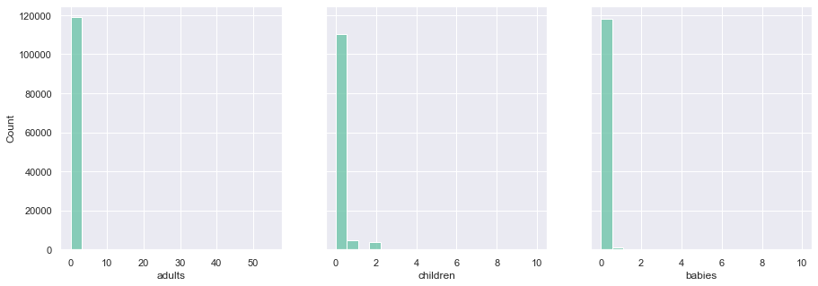

```python
sns.set_theme(style='darkgrid', palette='Set2')

fig, ax = plt.subplots(1, 3, figsize=(15,5), sharey=True)
for i, age in enumerate(['adults', 'children', 'babies']):
    sns.histplot(data=df, x=age, ax=ax[i])

plt.show()
```

Como es evidente que existen muestras con valores incorrectos en estos tres campos, eliminamos dichas muestras. Tomaremos como valor *outlier* a eliminar:

- adults: más de 6
- children: más de 4
- babies: más de 2

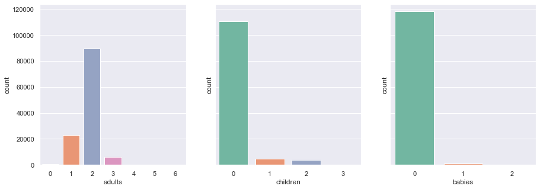

```python
df = df[(df['adults']<=6) & (df['children']<=4) & (df['babies']<=2)]

fig, ax = plt.subplots(1, 3, figsize=(15,5), sharey=True)
for i, age in enumerate(['adults', 'children', 'babies']):
    sns.countplot(data=df, x=age, ax=ax[i])
```

Podemos ver como la mayoría de las reservas son para dos personas y van sin niños. Las reservas con más de dos niños y más de un bebé son despreciables, al igual que las de más de tres adultos.

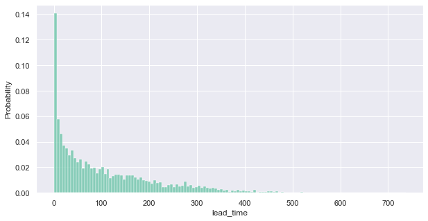

```python
plt.figure(figsize=(10,5))
sns.histplot(data=df, x='lead_time', stat='probability')
```

Podemos ver como una gran mayoría realiza la reserva con unos pocos días o semanas de antelación, pero también tenemos algunas que se realizan con un año e incluso más.

Vamos a ver la correlación entre el tiempo de antelación con el que se ha reservado y la cancelación de reservas.

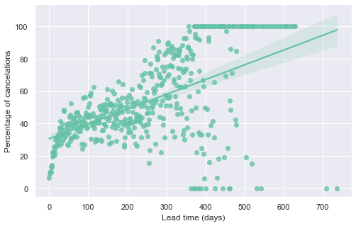

```python
lead_data = df.groupby('lead_time')['is_canceled'].mean()
plt.figure(figsize=(8,5))
sns.regplot(x=lead_data.index, y=lead_data.values*100)
plt.ylabel('Percentage of cancelations')
plt.xlabel('Lead time (days)')
```

Vemos como hay una clara correlación positiva entre el tiempo de antelación de la reserva y la cancelación, como era de esperar. Mayor tiempo de antelación en una reserva implica una mayor probabilidad de que esta sea cancelada. Entre las reservas que se hacen con unos pocos días de antelación, vemos como un porcentaje muy pequeño son canceladas.

Comprobamos ahora el número de noches de hotel reservadas entre semana y en fin de semana.

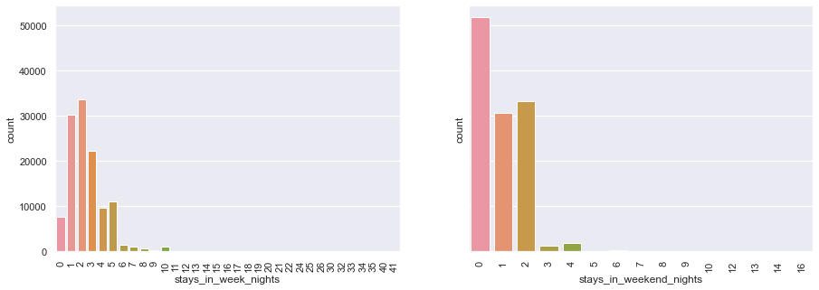

```python
fig, ax = plt.subplots(1, 2, figsize=(15,5), sharey=True)
sns.countplot(data=df, x='stays_in_week_nights', ax=ax[0])
plt.xticks(rotation=90)
ax[0].set_xticklabels(ax[0].get_xticklabels(),rotation=90)
sns.countplot(data=df, x='stays_in_weekend_nights', ax=ax[1])
```

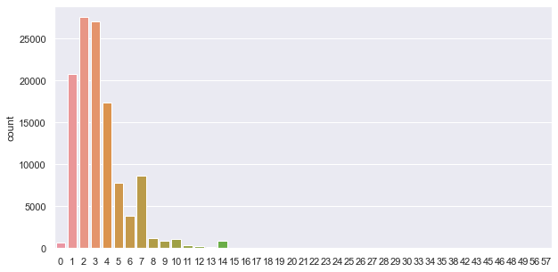

```python
plt.figure(figsize=(10,5))
sns.countplot(data=df, x=df['stays_in_week_nights']+df['stays_in_weekend_nights'])
```

Si representamos la suma de ambos valores obtenemos el número total de noches de la reserva. Vemos como las más habituales son las reservas de unas pocas noches (4 o menos), pero también llama la atención como hay un repunte con 7 y 14 noches, correspondientes a una o dos semanas. Nos planteamos eliminar las dos variables originales y sustituirlas por la suma de ellas, pero se piensa que el hecho de que una habitación esté reservada en fin de semana o no puede tener capacidad predictiva sobre la variable *is_canceled*. Al fin y al cabo, tiene sentido pensar que sea más probable cancelar una reserva de un fin de semana de ocio que una por un viaje de trabajo entre semana.

Por otro lado, nos damos cuenta de que hay un número de reservas que son para un total de cero noches. Como esto no es posible, tomamos estos datos como erróneos y eliminamos las muestras correspondientes del dataset.

```python
df = df[df['stays_in_week_nights']+df['stays_in_weekend_nights']>0]
```

Veamos ahora la distribución de valores de la variable *adr*, que indica el precio medio de la noche de habitación en la reserva.

```
count    118181.000000
mean        102.619447
std          50.010338
min          -6.380000
25%          70.000000
50%          95.000000
75%         126.000000
max        5400.000000
Name: adr, dtype: float64
```

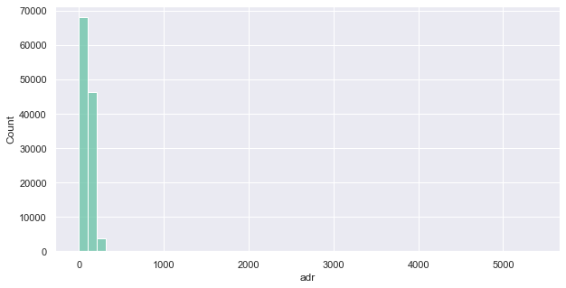

```python
print(df['adr'].describe())
plt.figure(figsize=(10,5))
sns.histplot(data=df, x='adr', bins=50)
```

Es evidente que existen valores erróneos en los datos:

- No es posible un coste medio de la habitación menor que cero.
- Parece poco probable que una habitación de hotel en Portugal pueda ser reservada por menos de 20€ la noche, poniendo un límite bastante bajo. Tomaremos las muestras con un valor inferior a este como erróneas y las eliminaremos.
- Parece poco probable que habitaciones se hayan reservado con un precio promedio de más de 5000€ la noche cuando el valor medio de todas las reservas es de 102€. Claramente son valores *outliers* que eliminaremos. Nos quedaremos sólo con los registros con un coste promedio menor o igual a 400€, que parece un límite superior razonable.

Podríamos realizar otros métodos de corrección de valores outliers como, por ejemplo, fijar a 20€ el *adr* de todas aquellas muestras con un valor inferior a este. Sin embargo, estos métodos de corrección pueden introducir errores (quizás un coste de 10€ fue un error y debería ser 100€, cuando nosotros lo fijaríamos a 20€) y en este caso no es necesario porque disponemos de un conjunto de datos con muchas muestras, las suficientes como para poder prescindir de unas cuantas y seguir contando con un número más que considerable.

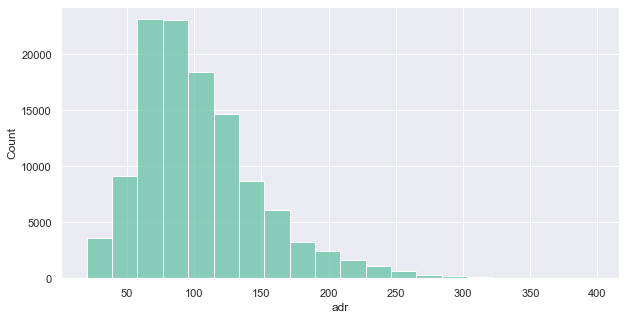

```python
df = df[(df['adr']<=400) & (df['adr']>=20)]
plt.figure(figsize=(10,5))
sns.histplot(data=df, x='adr', bins=20)
```

Ahora sí la distribución de coste promedio de habitación parece más realista y tiene sentido.

Evaluamos ahora el precio medio de la noche en función del tipo de hotel.

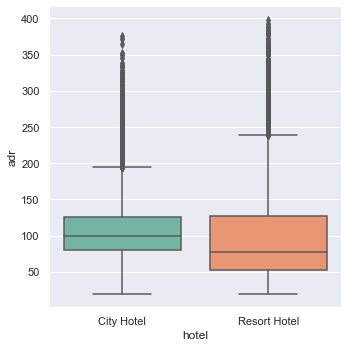

```python
sns.catplot(data=df, x='hotel', y='adr', kind='box', height=5)
```

Podemos observar como la mediana del precio medio pagado por noche es menor en el caso del resort que en el hotel de ciudad, pero también se observa cómo la desviación típica es mucho mayor. Vemos a continuación la evolución del precio por noche en ambos hoteles a lo largo del año.

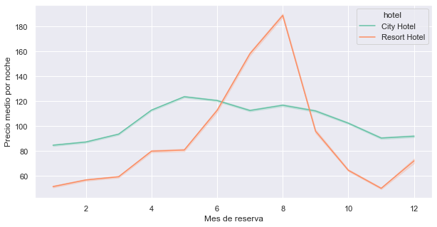

```python
plt.figure(figsize=(10,5))
sns.lineplot(data=df, x=df['arrival_date'].dt.month, y='adr', hue='hotel')
plt.xlabel('Mes de reserva')
plt.ylabel('Precio medio por noche')
```

De esta gráfica podemos sacar varias conclusiones que no sorprenden:

- Los meses más caros son los de verano, como cabría esperar.
- El precio del hotel de ciudad son mucho más estables a lo largo del año, mientras que el del resort es mucho más estacional. Esto justifica la mayor desviación típica en el precio de noche del resort.
- Sale más caro ir al resort que al hotel de ciudad en los meses de verano, mientras que en el resto del año ocurre lo contrario.

Veamos ahora la evolución de la tasa de cancelación a lo largo del año en los dos tipos de hoteles.

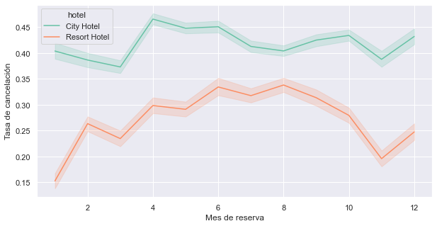

```python
plt.figure(figsize=(10,5))
sns.lineplot(data=df, x=df['arrival_date'].dt.month, y='is_canceled', hue='hotel')
plt.xlabel('Mes de reserva')
plt.ylabel('Tasa de cancelación')
```

De los resultados podemos extraer que la tasa de cancelación en el hotel de ciudad es mucho mayor en todo el año y que esta se mantiene más o menos estable a lo largo del año. Por otro lado, la tasa de cancelación en el resort es más baja y es más estacional: en los meses de verano es mayor, mientras que en los meses de invierno baja considerablemente.

Como es de esperar que el año no sea una variante relevante a la hora de predecir cancelaciones de reservas, y que el día del mes es una granularidad demasiado baja, nos quedaremos sólo con la variable mes de la fecha de reserva. A la hora de codificar una variable como el mes, tenemos que tener en cuenta dos cosas:

- Si la codificamos como numérica, con el número del mes (1->Enero... 12->Diciembre) tenemos el problema de que 'Diciembre' estará más cerca de, por ejemplo, 'Septiembre' que de 'Enero', y desde luego esta sería una interpretación errónea. Por lo tanto, de esta forma no captamos la naturaleza periódica de esta variable.
- Si la codificamos como categórica, teniendo 12 categorías distintas, una por mes, perdemos el sentido de distancia entre meses. Dicho de otra forma, 'Mayo' no estaría más cerca de 'Abril' que de 'Octubre', por ejemplo.

Para solucionar ambos problemas, vamos a codificarlo como variable numérica, pero tomando el seno y coseno del número de mes (variable cilíndrica). De esta forma mantenemos las distancias entre meses consecutivos, a la vez que mantenemos juntos el final del año (diciembre) con el comienzo del siguiente (enero), conservando su naturaleza periódica. Por lo tanto, para representar el mes acabaremos con dos variables de tipo flotante representando seno y coseno del mes.

```python
from sklearn.preprocessing import FunctionTransformer


def sin_transformer(period):
    return FunctionTransformer(lambda x: np.sin(x / period * 2 * np.pi))


def cos_transformer(period):
    return FunctionTransformer(lambda x: np.cos(x / period * 2 * np.pi))

df['arrival_month_sin'] = sin_transformer(12).fit_transform(df['arrival_date'].dt.month)
df['arrival_month_cos'] = cos_transformer(12).fit_transform(df['arrival_date'].dt.month)

df.drop('arrival_date', axis=1, inplace=True)
df.info()
```

```
<class 'pandas.core.frame.DataFrame'>
Int64Index: 116542 entries, 2 to 119389
Data columns (total 24 columns):
 #   Column                          Non-Null Count   Dtype
---  ------                          --------------   -----
 0   hotel                           116542 non-null  category
 1   is_canceled                     116542 non-null  bool
 2   lead_time                       116542 non-null  int64
 3   stays_in_weekend_nights         116542 non-null  int64
 4   stays_in_week_nights            116542 non-null  int64
 5   adults                          116542 non-null  int64
 6   children                        116542 non-null  int64
 7   babies                          116542 non-null  int64
 8   meal                            116542 non-null  category
 9   country                         116542 non-null  category
```

[output cut: 16 more lines]

Se ha consultado: https://scikit-learn.org/stable/auto_examples/applications/plot_cyclical_feature_engineering.html

Veamos ahora los países desde los que se realizan más reservas en los hoteles.

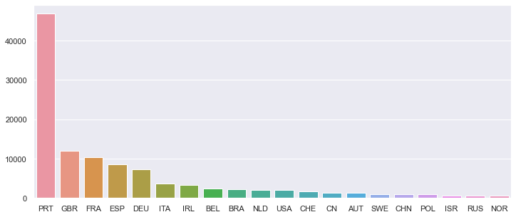

```python
top20 = df['country'].astype('string').value_counts().head(20)
plt.figure(figsize=(12,5))
sns.barplot(x=top20.index, y=top20.values)
```

Ninguna sorpresa aquí, puesto que los propios portugueses son los que más habitaciones reservan en los hoteles, y el resto de reservas son en su mayoría de países europeos. No hay sorpresa tampoco en que el primer país no europeo de la lista sea Brasil.

Es interesante analizar el país de procedencia de los clientes de los hoteles, pero esta variable catagórica contiene muchos valores distintos y por lo tanto muchas categorías posibles, la mayoría de ellas con muy pocas muestras, por lo que no es demasiado informativa en el estado en que está actualmente, y podría introducir mucho ruido en el modelo. Además, el número de variables se dispararía ya que realizando un codificación *one hote encoding* tendríamos tantas variables como países de procedencia menos uno. Contar con tantas variables no sólo complica el modelo y lo hace más lento, sino que puede provocar *overfitting*, creando un modelo que aprende muy bien las peculiaridades de un set de datos concreto en el entrenamiento (*train set*), pero que generalice mal al encontrarse con datos no vistos con anterioridad (*test set*).

Se podrían llegar a realizar otras transformaciones más complejas, e incluso descartar el atributo de país de procedencia, pero se opta por simplificar esta variable en una booleana que indique si la reserva es nacional (0) o internacional (1). Parece una decisión interesante porque por un lado el riesgo de que una reserva sea cancelada pensamos que puede estar correlada con que el viaje sea nacional o no (seguramente un viaje de menor distancia, cuyo camino seguramente se haga en coche, es más probable de ser cancelado) y por el otro no tenemos tantas categorías los inconvenientes que hemos visto que conlleva.

```python
df['is_international'] = df['country'] != 'PRT'
df.drop('country', axis=1, inplace=True)
df['is_international'].value_counts(normalize=True)
```

```
True     0.598377
False    0.401623
Name: is_international, dtype: float64
```

```python
df.groupby('is_international').mean()['is_canceled']
```

```
is_international
False    0.580908
True     0.237639
Name: is_canceled, dtype: float64
```

Confirmamos nuestras sospechas, ya que el 58% de las reservas nacionales son canceladas, mientras que sólo el 23% de las internacionales lo son. No sólo hemos creado una variable que nos aporta información, sino que ésta parece ser **muy buena** para predecir la cancelación de una reserva de hotel, ya que tendrá una correlación muy alta.

Analizamos ahora los regímenes de comidas que se contratan por tipo de hotel.

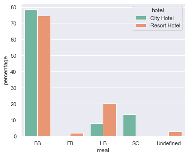

```python
plt.figure(figsize=(6,5))
per=df.groupby('hotel')['meal'].value_counts(normalize=True).rename('percentage').mul(100).reset_index()
per.rename({'level_1':'meal'}, axis=1, inplace=True)
sns.barplot(data=per, x='meal', y='percentage', hue='hotel')
```

Vemos como un porcentage muy similar en ambos hoteles contratan la habitación con desayuno (BB) y son mayoría (75-80%). También se puede observar como hay muchos más que contratan media pensión (HB) en el resort, y sólo en éste se contrata el regimen de pensión completa (FB), seguramente porque en el hotel de ciudad ni siquiera se ofrezca. Las categorías *SC* y *Undefined* representan en realidad un mismo tipo de reserva, en la que no se ha contratado ningún tipo de comida. Por lo tanto, unificaremos estos conceptos bajo una sóla categoría *SC*. Vemos que bastantes reservas optan por esta reserva en el hotel de ciudad, mientras que en el resort esta opción es minoritaria.

```
<class 'pandas.core.frame.DataFrame'>
RangeIndex: 8 entries, 0 to 7
Data columns (total 3 columns):
 #   Column      Non-Null Count  Dtype
---  ------      --------------  -----
 0   hotel       8 non-null      category
 1   meal        8 non-null      category
 2   percentage  8 non-null      float64
dtypes: category(2), float64(1)
memory usage: 536.0 bytes
```

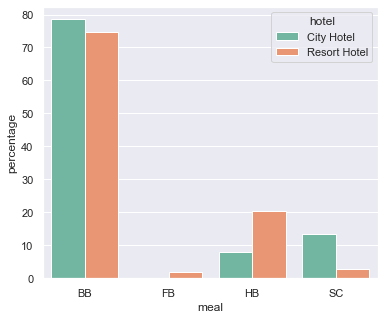

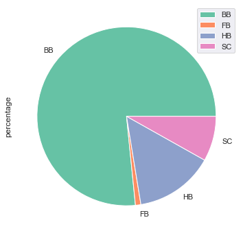

```python
df['meal'] = df['meal'].replace('Undefined', 'SC')
plt.figure(figsize=(6,5))
per=df.groupby('hotel')['meal'].value_counts(normalize=True).rename('percentage').mul(100).reset_index()
per.rename({'level_1':'meal'}, axis=1, inplace=True)
sns.barplot(data=per, x='meal', y='percentage', hue='hotel')
per.info()
per.groupby('meal').sum().plot.pie(y='percentage', figsize=(6, 6))
```

Observamos la distribución de las reservas por segmento de mercado y canal de distribución según el tipo de hotel.

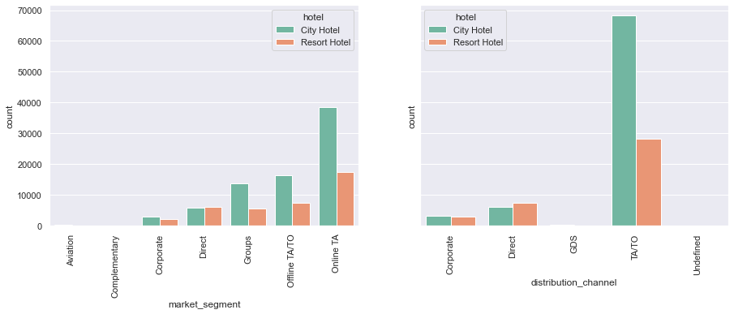

```python
fig, ax = plt.subplots(1, 2, figsize=(15,5), sharey=True)
g = sns.countplot(data=df, x='market_segment', hue='hotel', ax=ax[0])
ax[0].tick_params(axis='x', rotation=90)
g = sns.countplot(data=df, x='distribution_channel', hue='hotel', ax=ax[1])
ax[1].tick_params(axis='x', rotation=90)
```

Vamos ahora el tipo de depósito realizado por los clientes a la hora de hacer la reserva en base a si finalmente esta ha sido o no cancelada.

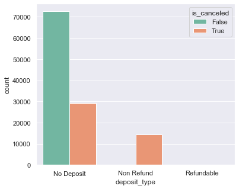

```python
plt.figure(figsize=(6,5))
sns.countplot(data=df, x='deposit_type', hue='is_canceled')
```

Este resultado parece anti intuitivo, puesto que no parece lógico que todos los que optan por realizar una reserva sin reembolso acaben cancelándola. Vemos las medias de los valores según el tipo de depósito.

```python
df.groupby('deposit_type').mean()
```

| deposit_type | is_canceled | lead_time | stays_in_weekend_nights | stays_in_week_nights | adults | children | babies | is_repeated_guest | previous_cancellations | previous_bookings_not_canceled | adr | required_car_parking_spaces | total_of_special_requests | arrival_month_sin | arrival_month_cos | is_international |
| --- | --- | --- | --- | --- | --- | --- | --- | --- | --- | --- | --- | --- | --- | --- | --- | --- |
| No Deposit | 0.287378 | 90.025574 | 0.981910 | 2.583320 | 1.870767 | 0.119333 | 0.008809 | 0.031152 | 0.034766 | 0.135440 | 106.039156 | 0.07073 | 0.654080 | -0.058782 | -0.151607 | 0.679879 |
| Non Refund | 0.993680 | 212.998764 | 0.622407 | 2.091084 | 1.811513 | 0.000618 | 0.000000 | 0.004396 | 0.412076 | 0.010647 | 89.699898 | 0.00000 | 0.001786 | -0.042761 | -0.130656 | 0.027064 |
| Refundable | 0.212500 | 151.975000 | 0.962500 | 2.825000 | 1.906250 | 0.025000 | 0.000000 | 0.025000 | 0.000000 | 0.018750 | 77.049875 | 0.12500 | 0.143750 | 0.485048 | -0.204006 | 0.712500 |

Por todo esto, y teniendo en cuenta que no sabemos interpretar correctamente esta variable, optamos por desecharla y no tenerla en cuenta a la hora de realizar nuestro modelado.

```python
df.drop('deposit_type', axis=1, inplace=True)
```

Vemos también la distribución de tipo de cliente en relación a si finalmente cancela o no la reserva.

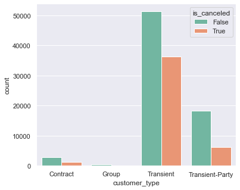

```python
plt.figure(figsize=(6,5))
sns.countplot(data=df, x='customer_type', hue='is_canceled')
```

Parece que la variable tipo de cliente influye bastante en las probabilidades de que la reserva sea cancelada. Claramente el "Transient-Party" tiene muchas menos probabilidades de ser cancelado que el "Transient". Según la documentación del dataset en Kaggle, "Transient" es el cliente individual, que no pertenece a un grupo, mientras que "Transient-party" son los que tampoco pertenecen a un grupo, pero que han reservado más de una habitación. Por lo tanto, es de esperar que en este último haya más familias que reservan más de una habitación.

Vemos ahora las distribución de tipo de habitación según el tipo de hotel.

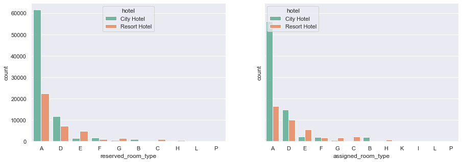

```python
fig, ax = plt.subplots(1, 2, figsize=(15,5), sharey=True)
sns.countplot(data=df, x='reserved_room_type', hue='hotel', ax=ax[0], order = df['reserved_room_type'].value_counts().index)
sns.countplot(data=df, x='assigned_room_type', hue='hotel', ax=ax[1], order = df['assigned_room_type'].value_counts().index)
```

Vemos como la habitación más habitual en ambos hoteles es la *A*, y que no todos los tipos de habitación existen en ambos hoteles. No sabemos las etiquetas de las categorías de habitaciones que tenemos a qué tipo de habitación corresponden, pero es de esperar que la *A* sea la habitación estándar, en base al número de reservas realizadas. También podemos observar que no siempre se asigna la la misma habitación que la que se ha reservado, y que incluso hay una categoría de habitación reservada que no existe en las reservas.

Observamos ahora la distribución de precio medio por noche (*adr*) en función del tipo de habitación reservada.

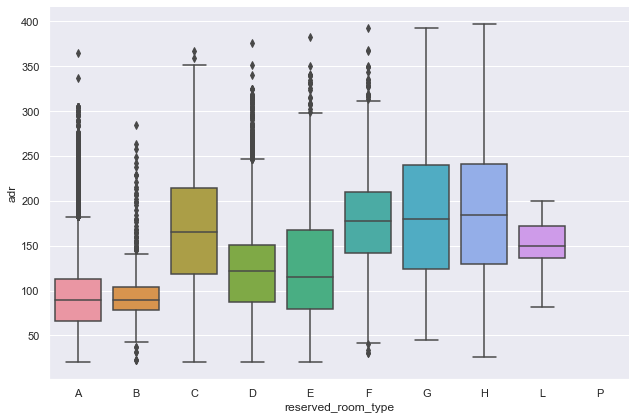

```python
sns.catplot(data=df, x='reserved_room_type', y='adr', kind='box', height=6, aspect=1.5)
```

Vemos como efectivamente hay habitaciones con una mediana de precio más baja (tipo A, las más reservada) y otras con una mayor, hasta de casi el doble. De la misma manera, hay tipos de habitaciones con una menor diferencia entre los precios pagados por noches y otras con unas diferencias mayores.

Nos planteamos si puede influir en la decisión de cancelar la reserva el hecho de que el hotel asigne una habitación distinta a la reservada. Creamos una nueva variable que indique este hecho.

```python
df['room_changed'] = df['assigned_room_type'].astype('string') != df['reserved_room_type'].astype('string')
df['room_changed'] = df['room_changed'].astype('bool')
df.groupby('room_changed')['is_canceled'].mean()
```

```
room_changed
False    0.418633
True     0.054671
Name: is_canceled, dtype: float64
```

Vemos como efectivamente existen porcentajes de cancelación mucho menores en el caso de que hayan asignado una habitación distinta a la resevada. Esto se puede deber a que cambios en el tipo de habitación suelen implicar el cambio a una de nivel superior, algo que anima al cliente a no cancelar la reserva, ya que va a disfrutar de una habitación superior habiendo pagado una de nivel inferior. Vista la diferencia en esta variable, parece muy informativa y la utilizaremos para nuestro modelo. Podríamos mantener también las de tipo de habitación reservada y asignada, pero al encontrar esta variable muy informativa y para reducir el número de variables, optamos por eliminarlas.

```python
df.drop(['reserved_room_type', 'assigned_room_type'], axis=1, inplace=True)
```

Visualizamos la matriz de correlaciones entre las variables numéricas.

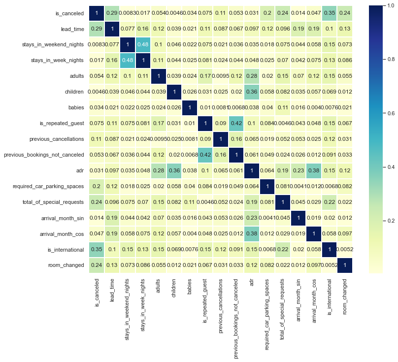

```python
plt.figure(figsize=(12,10))
sns.heatmap(df.corr().abs(), linewidths=1, annot=True, cmap="YlGnBu")
```

Podemos observar que hay muchas variables que no parecen estar muy correladas con la cancelación de la reserva (*is_canceled*), pero hay otras que sí tienen una correlación bastante fuerte. La variable *lead_time*, como ya habíamos visto, tiene una alta correlación con *is_canceled*, y también lo tienen las variables nuevas que hemos generado *is_international* y *room_chaanged*.

Hay que tener en cuenta que el hecho de que una variable no esté correlada con otra no quiere decir que no tenga capacidad predictiva sobre esta, pues puede haber entre ellas una relación no lineal, que no captará la correlación. Lo contrario, sin ambargo, sí que es cierto, y por lo tanto correlaciones altas implicarán cierta capacidad predictiva.

Podemos ver otras correlaciones fuertes que ya hemos comentado, como la del coste promedio de la habitación con el las variables que definen el mes (seno y coseno) o el mismo coste con el número de adultos y niños en la reserva.

De todo este análisis exploratorio ya tenemos algunos resultados interesantes que nos pueden ayudar en nuestro objetivo de optimizar las reservas de noches de hotel, y todo antes de realizar ningún modelado:

- No son especialmente interesantes la reservas realizadas con mucha antelación, pues son más propensas a ser canceladas.
- Son más interesantes las reservas de clientes internacionales. Por lo tanto, podríamos dirigir nuestros esfuerzos de márkering en este tipo de cliente.
- Las reservas de resorts son menos probables de ser canceladas.
- Las reservas de más de una habitación son más interesantes.

## Análisis PCA

```python
df.info()
```

```
<class 'pandas.core.frame.DataFrame'>
Int64Index: 116542 entries, 2 to 119389
Data columns (total 22 columns):
 #   Column                          Non-Null Count   Dtype
---  ------                          --------------   -----
 0   hotel                           116542 non-null  category
 1   is_canceled                     116542 non-null  bool
 2   lead_time                       116542 non-null  int64
 3   stays_in_weekend_nights         116542 non-null  int64
 4   stays_in_week_nights            116542 non-null  int64
 5   adults                          116542 non-null  int64
 6   children                        116542 non-null  int64
 7   babies                          116542 non-null  int64
 8   meal                            116542 non-null  category
 9   market_segment                  116542 non-null  category
 10  distribution_channel            116542 non-null  category
 11  is_repeated_guest               116542 non-null  bool
 12  previous_cancellations          116542 non-null  int64
 13  previous_bookings_not_canceled  116542 non-null  int64
 14  customer_type                   116542 non-null  category
 15  adr                             116542 non-null  float64
 16  required_car_parking_spaces     116542 non-null  int64
 17  total_of_special_requests       116542 non-null  int64
 18  arrival_month_sin               116542 non-null  float64
 19  arrival_month_cos               116542 non-null  float64
 20  is_international                116542 non-null  bool
 21  room_changed                    116542 non-null  bool
dtypes: bool(4), category(5), float64(3), int64(10)
memory usage: 17.5 MB
```

Para hacer el análisis PCA tenemos que tener en cuenta que sólo podremos trabajar con variables numéricas y no categóricas. Nos plantemos la posibilidad de realizar una codificación numérica de las categorías con, por ejemplo, *one hot encoding*, pero PCA tampoco trabaja correctamente con variables de tipo binario. Por lo tanto , optamos por hacer el análisis PCA teniendo en cuenta sólo las variables numéricas, sin tener en cuenta las categóricas.

```python
from pandas.api.types import is_numeric_dtype

num_var = [colname for colname, coltype in df.dtypes.iteritems() if is_numeric_dtype(coltype)]
num_var
```

```
['is_canceled',
 'lead_time',
 'stays_in_weekend_nights',
 'stays_in_week_nights',
 'adults',
 'children',
 'babies',
 'is_repeated_guest',
 'previous_cancellations',
 'previous_bookings_not_canceled',
 'adr',
 'required_car_parking_spaces',
 'total_of_special_requests',
 'arrival_month_sin',
 'arrival_month_cos',
 'is_international',
 'room_changed']
```

```python
df.describe()
```

|  | lead_time | stays_in_weekend_nights | stays_in_week_nights | adults | children | babies | previous_cancellations | previous_bookings_not_canceled | adr | required_car_parking_spaces | total_of_special_requests | arrival_month_sin | arrival_month_cos |
| --- | --- | --- | --- | --- | --- | --- | --- | --- | --- | --- | --- | --- | --- |
| count | 116542.000000 | 116542.000000 | 116542.000000 | 116542.000000 | 116542.000000 | 116542.000000 | 116542.000000 | 116542.000000 | 116542.000000 | 116542.000000 | 116542.000000 | 1.165420e+05 | 116542.000000 |
| mean | 105.471984 | 0.936976 | 2.522164 | 1.863414 | 0.104374 | 0.007697 | 0.081850 | 0.119691 | 103.958316 | 0.061969 | 0.571897 | -5.603401e-02 | -0.149062 |
| std | 106.963902 | 0.991543 | 1.880214 | 0.479935 | 0.398192 | 0.088757 | 0.778297 | 1.434304 | 46.310478 | 0.244388 | 0.791681 | 7.227654e-01 | 0.672502 |
| min | 0.000000 | 0.000000 | 0.000000 | 0.000000 | 0.000000 | 0.000000 | 0.000000 | 0.000000 | 20.000000 | 0.000000 | 0.000000 | -1.000000e+00 | -1.000000 |
| 25% | 19.000000 | 0.000000 | 1.000000 | 2.000000 | 0.000000 | 0.000000 | 0.000000 | 0.000000 | 71.360000 | 0.000000 | 0.000000 | -8.660254e-01 | -0.866025 |
| 50% | 71.000000 | 1.000000 | 2.000000 | 2.000000 | 0.000000 | 0.000000 | 0.000000 | 0.000000 | 95.000000 | 0.000000 | 0.000000 | -2.449294e-16 | -0.500000 |
| 75% | 162.000000 | 2.000000 | 3.000000 | 2.000000 | 0.000000 | 0.000000 | 0.000000 | 0.000000 | 126.000000 | 0.000000 | 1.000000 | 5.000000e-01 | 0.500000 |
| max | 709.000000 | 16.000000 | 40.000000 | 4.000000 | 3.000000 | 2.000000 | 26.000000 | 72.000000 | 397.380000 | 8.000000 | 5.000000 | 1.000000e+00 | 1.000000 |

Se ha consultado:

https://stackoverflow.com/questions/19900202/how-to-determine-whether-a-column-variable-is-numeric-or-not-in-pandas-numpy/46423535

Como tenemos escalas muy diferentes en todas las variables numéricas, debemos escalar las variables para que estén en el mismo rango y el algoritmo PCA pueda obtener un buen resultado. Si no se realiza este paso, las variables numéricas con más rango tendrán mucho más peso y serán las que al final marquen las componentes PCA resultantes, dejando a las demás prácticamente sin valor.

```python
from sklearn.decomposition import PCA
from sklearn.preprocessing import StandardScaler
from sklearn.pipeline import Pipeline

n_pca = 10

pipeline = Pipeline([('scaling', StandardScaler()), ('pca', PCA(n_components=n_pca))])
pca_comp = pipeline.fit_transform(df[num_var].drop('is_canceled', axis=1))
pca_dict = {f'pca{i+1}':pca_comp[:,i] for i in range(n_pca)}
pca_dict['is_canceled'] = df['is_canceled'].values
pca_df = pd.DataFrame(pca_dict)
pca_df.info()
```

```
<class 'pandas.core.frame.DataFrame'>
RangeIndex: 116542 entries, 0 to 116541
Data columns (total 11 columns):
 #   Column       Non-Null Count   Dtype
---  ------       --------------   -----
 0   pca1         116542 non-null  float64
 1   pca2         116542 non-null  float64
 2   pca3         116542 non-null  float64
 3   pca4         116542 non-null  float64
 4   pca5         116542 non-null  float64
 5   pca6         116542 non-null  float64
 6   pca7         116542 non-null  float64
 7   pca8         116542 non-null  float64
 8   pca9         116542 non-null  float64
 9   pca10        116542 non-null  float64
 10  is_canceled  116542 non-null  bool
dtypes: bool(1), float64(10)
memory usage: 9.0 MB
```

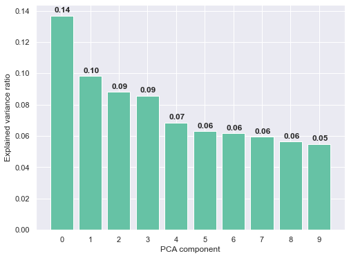

```python
pca_var = pipeline['pca'].explained_variance_ratio_
plt.figure(figsize=(8,6))
plt.bar(x=range(n_pca), height=pca_var)
plt.xlabel('PCA component')
plt.ylabel('Explained variance ratio')
plt.xticks(list(range(n_pca)))

for i, v in enumerate(pca_var):
    plt.gca().text(i-0.25, v+0.002, f'{v:.2f}', fontweight='bold')
plt.show()
```

Una transformación PCA nos puede servir para dos cosas:

- Reducir la dimensionalidad del problema. Esto puede sernos interesante si con un conjunto reducido de las dimensiones PCA mantenemos casi toda la varianza de las dimensiones originales, reduciendo el número de variables y por lo tanto la complejidad del modelo. En este caso en particular, no parece especialmente interesante, ya que partimos de 16 dimensiones originales y con las primeras 10 dimensiones PCA que hemos calculado no tenemos todavía un porcentaje demasiado alto de la varianza (79%). Para tener un porcentaje más alto (90%+) necesitaríamos más dimensiones, y la reducción frente a las 16 numéricas originales no sería demasiado grande. A pasar de todo, puede sernos interesante reducir la dimensionalidad del modelo si el modelo no generaliza bien (tenemos *overfitting*) para reducir la varianza, pero será algo que habrá que tratar cuando se realice la validación del modelo.
- Representar visualmente los datos en 2D o 3D. Para representar los datos en 2D, no quedamos con las dos primeras componentes principales. Sin embargo, en este caso estas dos componentes PCA no nos aportan más que el 24% de la varianza original, un porcentaje muy bajo, por lo que la representación 2D de las muestras no va a ser muy representativa. Además, hay que tener en cuenta que sólamente estamos tratando con las componentes numéricas que tenemos, obviando las categóricas, por lo que la información final que estamos representando de estas muestras es muy limitada respecto a la que tenemos.

Como la cantidad de muestras es muy grande, representamos la densidad de puntos con *kde* (kernel density estimation) en lugar de cada punto de forma indivudual.

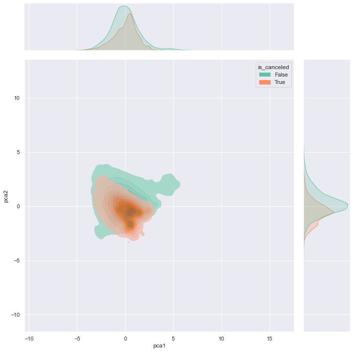

```python
sns.jointplot(data=pca_df, x='pca1', y='pca2', hue='is_canceled', kind='kde', fill=True, joint_kws={'alpha': 0.7}, height=10)
```

Pese a contar con muy poca información representada visualmente respecto a la total de la que disponemos, ya se pueden ver diferencias claras en la distribución marginal de densidades en ambas componentes representadas, lo que hace pensar que en el modelo completo podamos tener una separación razonablemente buena entre las dos clases.

# Análisis FAMD

Para solucionar el problema de que con PCA sólo podemos transformar las variables numéricas, además del hecho de que no trabaja correctamente con variables binarias, utilizamos un algoritmo alternativo: FAMD (Factor Analysis of Mixed Data), un algoritmo con el que se puede trabajar con ambos tipos de variables numéricas y categóricas. Se trata de un método muy parecido a PCA, y de hecho utiliza éste para las variables numéricas, pero utiliza además MCA (*multiple correspondence analysis*) para las variables categóricas. De esta forma:

- Las variables numéricas continuas las trataremos como variables numéricas a las que el algoritmo aplicará PCA.
- A las variables categóricas el algoritmo aplicará MCA.
- Las variables booleanas las trataremos como variables categóricas para aplicar MCA, ya que PCA no trabaja bien con estas variables.

*Nota: En este caso, no aplicamos normalización antes del algoritmo sobre las variables numéricas, porque la implementación de PCA de la librería prince ya realiza esta normalización por defecto.*

Se ha consultado:

https://towardsdatascience.com/5-must-know-dimensionality-reduction-techniques-via-prince-e6ffb27e55d1

https://datascience.stackexchange.com/questions/32895/data-scaling-before-pca-how-to-deal-with-categorical-values

```python
from prince import FAMD
n_famd=10

# Convertivos provisionalmente las columnas de tipo 'category' a tipo 'object'
# porque hay un bug en la versión de prince que produce un error si todas las
# variables categóricas son 'category' en lugar de 'object'
df_object = pd.DataFrame()
for feat in df:
    if (df[feat].dtype.name == 'category') | (df[feat].dtype.name == 'bool'):
        df_object[feat] = df[feat].astype('object')
    else:
        df_object[feat] = df[feat]

famd = FAMD(n_components=n_famd)
famd_df = famd.fit_transform(df_object.drop('is_canceled', axis=1))
famd_df.info()
```

```
<class 'pandas.core.frame.DataFrame'>
Int64Index: 116542 entries, 2 to 119389
Data columns (total 10 columns):
 #   Column  Non-Null Count   Dtype
---  ------  --------------   -----
 0   0       116542 non-null  float64
 1   1       116542 non-null  float64
 2   2       116542 non-null  float64
 3   3       116542 non-null  float64
 4   4       116542 non-null  float64
 5   5       116542 non-null  float64
 6   6       116542 non-null  float64
 7   7       116542 non-null  float64
 8   8       116542 non-null  float64
 9   9       116542 non-null  float64
dtypes: float64(10)
memory usage: 13.8 MB
```

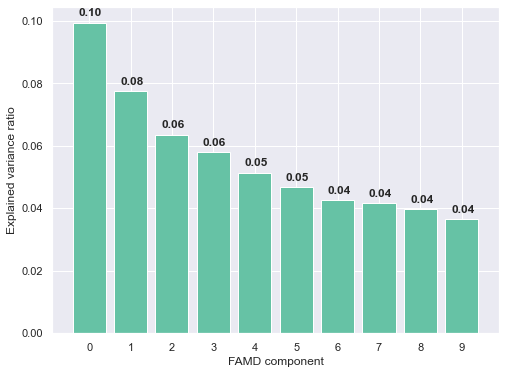

```python
famd_var = famd.explained_inertia_
plt.figure(figsize=(8,6))
plt.bar(x=range(n_pca), height=famd_var)
plt.xlabel('FAMD component')
plt.ylabel('Explained variance ratio')
plt.xticks(list(range(n_famd)))

for i, v in enumerate(famd_var):
    plt.gca().text(i-0.25, v+0.002, f'{v:.2f}', fontweight='bold')
plt.show()
```

De la misma manera que antes, como la cantidad de muestras es muy grande, representamos la densidad de puntos con *kde* (kernel density estimation) en lugar de cada punto de forma individual.

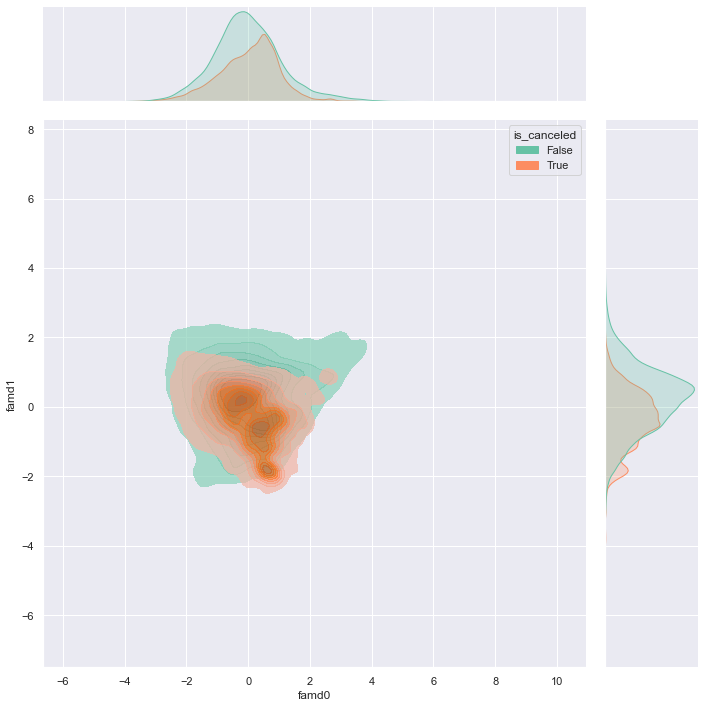

```python
famd_df.rename(columns=lambda s: 'famd'+str(s), inplace=True)
famd_df['is_canceled'] = df['is_canceled'].values
sns.jointplot(data=famd_df, x='famd0', y='famd1', hue='is_canceled', kind='kde', fill=True, joint_kws={'alpha': 0.7}, height=10)
```

Se puede observar de las densidades marginales de las dos primeras componentes FAMD (especialmente de la primera) que ambas clases tienen una separación razonablemente buena, teniendo en cuenta que con estas dos componentes apenas estamos captando el 18% de la varianza original.

Por último, tomamos una muestra de 1000 del dataset original y representamos en el espacio los puntos de foma individual.

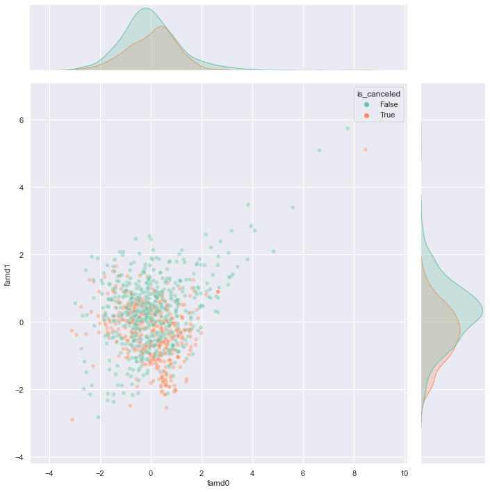

```python
sample_famd_df = famd_df.sample(n=1000, random_state=42, axis=0)
sns.jointplot(data=sample_famd_df, x='famd0', y='famd1', hue='is_canceled', height=10, alpha=0.4)
```

Se puede ver quizás de forma más clara que con *kde* la diferencia en la distribución de las dos clases en el espacio de las primeras dos componentes principales de FAMD. Pese a que están muy solapados, los puntos de la clase positiva de *is_canceled* se concentran más en la parte baja derecha. Nuevamente, hay que tener en cuenta que la representación en 2D que estamos haciendo de los puntos es muy limitada, ya que con las dos primeras componentes principales apenas estamos captando el 18% de la varianza original.

## Construcción de conjunto de datos final

A la hora de preparar los datos para el modelo, tendremos dos opciones:

1. Introducir en el modelo todas las variables con las que hemos acabado despues de realizar todas las limpiezas y transformaciones pertinentes. Contaremos con variables numéricas, binarias y categóricas. Las de tipo categórico tendremos que codificarlas con *one hot encoding*, por lo que acabarán siendo también binarias. Las variables numéricas deberemos normalizarlas (*feature scaling*) si hacemos uso de algunos de los algoritmos de clasificación que así lo requiera, pero este es un paso opcional que dependerá del algoritmo de clasificación que utilicemos.
2. Introducir en el modelo las componentes FAMD. En este caso, deberemos determinar cuántas componentes introducir, que podrá ser un parámetro que podremos variar o bien para reducir el tamaño del modelo sin perder apenas rendimiento, o bien para reducir la varianza si tenemos *overfitting*. En este caso, este parámetro será uno con los que podremos jugar para obtener un mejor modelo mediante un proceso de validación (*hyperparamater tuning*). En este caso, tenemos todas las variables de tipo numérico (*float*) y contaremos con la desventaja de perder la noción del significado de cada una de las variables con las que trabajaremos en el modelo

Habría una tercera opción, que sería la de introducir las componentes PCA que hemos calculado, pero tenemos el doble problema de que tenemos variables categóricas cuya información directamente perdemos y booleanas que sabemos que no trabajan bien con PCA. Por lo tanto, este método lo descartaremos.

También separaremos la variable de clase objetivo (y) de las variables predictoras (X).

Preparamos el juego de datos para la primera de las opciones:

```python
df.info()
```

```
<class 'pandas.core.frame.DataFrame'>
Int64Index: 116542 entries, 2 to 119389
Data columns (total 22 columns):
 #   Column                          Non-Null Count   Dtype
---  ------                          --------------   -----
 0   hotel                           116542 non-null  category
 1   is_canceled                     116542 non-null  bool
 2   lead_time                       116542 non-null  int64
 3   stays_in_weekend_nights         116542 non-null  int64
 4   stays_in_week_nights            116542 non-null  int64
 5   adults                          116542 non-null  int64
 6   children                        116542 non-null  int64
 7   babies                          116542 non-null  int64
 8   meal                            116542 non-null  category
 9   market_segment                  116542 non-null  category
 10  distribution_channel            116542 non-null  category
 11  is_repeated_guest               116542 non-null  bool
 12  previous_cancellations          116542 non-null  int64
 13  previous_bookings_not_canceled  116542 non-null  int64
 14  customer_type                   116542 non-null  category
 15  adr                             116542 non-null  float64
 16  required_car_parking_spaces     116542 non-null  int64
 17  total_of_special_requests       116542 non-null  int64
 18  arrival_month_sin               116542 non-null  float64
 19  arrival_month_cos               116542 non-null  float64
 20  is_international                116542 non-null  bool
 21  room_changed                    116542 non-null  bool
dtypes: bool(4), category(5), float64(3), int64(10)
memory usage: 17.5 MB
```

```python
X = pd.get_dummies(df.drop('is_canceled', axis=1), dtype=bool, drop_first=True)
y = df['is_canceled']
X.info()
```

```
<class 'pandas.core.frame.DataFrame'>
Int64Index: 116542 entries, 2 to 119389
Data columns (total 33 columns):
 #   Column                          Non-Null Count   Dtype
---  ------                          --------------   -----
 0   lead_time                       116542 non-null  int64
 1   stays_in_weekend_nights         116542 non-null  int64
 2   stays_in_week_nights            116542 non-null  int64
 3   adults                          116542 non-null  int64
 4   children                        116542 non-null  int64
 5   babies                          116542 non-null  int64
 6   is_repeated_guest               116542 non-null  bool
 7   previous_cancellations          116542 non-null  int64
 8   previous_bookings_not_canceled  116542 non-null  int64
 9   adr                             116542 non-null  float64
```

[output cut: 25 more lines]

Preparamos a continuación el set de datos para la segunda de las opciones, utilizando las componentes de la transformación FAMD. Primero realizamos una transformación FAMD con el mismo número de dimensiones originales.

```python
n_famd = df.drop('is_canceled', axis=1).shape[1]
famd = FAMD(n_components=n_famd)
famd_df = famd.fit_transform(df_object.drop('is_canceled', axis=1))
famd_df.rename(columns=lambda s: 'famd'+str(s), inplace=True)

X_famd = famd_df
y_famd = df['is_canceled']
X_famd.info()
```

```
<class 'pandas.core.frame.DataFrame'>
Int64Index: 116542 entries, 2 to 119389
Data columns (total 21 columns):
 #   Column  Non-Null Count   Dtype
---  ------  --------------   -----
 0   famd0   116542 non-null  float64
 1   famd1   116542 non-null  float64
 2   famd2   116542 non-null  float64
 3   famd3   116542 non-null  float64
 4   famd4   116542 non-null  float64
 5   famd5   116542 non-null  float64
 6   famd6   116542 non-null  float64
 7   famd7   116542 non-null  float64
 8   famd8   116542 non-null  float64
 9   famd9   116542 non-null  float64
 10  famd10  116542 non-null  float64
 11  famd11  116542 non-null  float64
 12  famd12  116542 non-null  float64
 13  famd13  116542 non-null  float64
 14  famd14  116542 non-null  float64
 15  famd15  116542 non-null  float64
 16  famd16  116542 non-null  float64
 17  famd17  116542 non-null  float64
 18  famd18  116542 non-null  float64
 19  famd19  116542 non-null  float64
 20  famd20  116542 non-null  float64
dtypes: float64(21)
memory usage: 23.6 MB
```

Por último, en cualquiera de los dos casos anteriores, tendremos que apartar un porcentaje de las muestras que tenemos para utilizar como conjunto de test, para evaluar el comportamiento final de nuestro modelo con datos no vistos en la fase de entrenamiento. Típicamente se reserva el 20% de las muestras con este propósito, y es lo que haremos.

```python
from sklearn.model_selection import train_test_split

X_train, X_test, y_train, y_test = train_test_split(X, y, test_size=0.2, random_state=42)
print(X_train.shape)
print(X_test.shape)
```

```
(93233, 33)
(23309, 33)
```

# Minería de datos: PRA2 - Proyecto de minería de datos

### Autor: **Gerson Villalba Arana**

### Enero 2022

**Nota previa:** El set de datos elegido para la primera parte de la práctica, PRA1, ha sido seleccionado para utilizar algoritmos supervisados y poder hacer una clasificación binaria, ya que contienen etiqueta o variable objetivo. Para aplicar algoritmos no supervisados sobre este conjunto de datos, nos olvidaremos de que tenemos dos clases objetivo (reserva va a ser o no cancelada), sino que tendremos una serie de reservas que queremos segmentar en un número indeterminado de clusters atendiendo a las variables que las definen. Esto puede tener distintas aplicaciones, como la de aplicar descuentos sobre tipos de reservas, hacer promociones, etc. Por lo tango, en la aplicación de estos algoritmos no supervisados tal y como lo planteamos, el objetivo del problema cambia completamente respecto al que habíamos propuesto en la PRA1, y desconoceríamos a priori el número de clusters en los que dividir las muestras.

## **Ejercicio 1**: Aplicar un modelo no supervisado basado en el concepto de distancia

### Generación del modelo no supervisado

Para la generación de los modelos no supervisados, podemos utilizar todas las muestras que tenemos disponibles, ya que no necesitamos reservar un conjunto de datos de test, como sí lo necesitamos en los modelos supervisados. Sin embargo, en este caso tenemos muchas muestras y ciertos cálculos algorítmicos se prolongan durante mucho tiempo. Es por ello que seleccionamos de forma aleatoria un subconjunto de las muestras de las que disponemos y trabajaremos sólo con ellas para hacerlo de una forma más cómoda, si bien en un caso real no desaprovecharíamos la oportunidad de tener un dataset tan grande.

```python
print(f'The full dataset has {X.shape[0]} samples')
X_sub = X.sample(10000, random_state=41)
print(f'The reduced dataset has {X_sub.shape[0]} samples')
```

```
The full dataset has 116542 samples
The reduced dataset has 10000 samples
```

Al tratarse de un método basado en distancia, es importante normalizar previamente los datos para que el modelo no sea sensible a la distintas escalas que puedan presentar -y presentan- las distintas valiables de entrada.

```python
from sklearn.preprocessing import StandardScaler

X_norm = StandardScaler().fit_transform(X_sub)
```

```python
from sklearn.cluster import KMeans

n_clusters = 4
k_means = KMeans(n_clusters=n_clusters, random_state=41)
k_means.fit(X_norm)
```

```
KMeans(n_clusters=4, random_state=41)
```

En un caso en el que tuviésemos menos variables de entrada al modelo, o bien pudiésemos reducir las variables iniciales a 2 o 3 con técnicas de reducción de dimensionalidad como PCA, podríamos representar gráficamente los puntos del dataset (o una muestra) y su asignación en clusters. Sin embargo, tenemos muchas variables y con las dos primeras componentes de la descomposición FAMD sólo obtenemos un 18% de la varianza original de los datos, por lo que no merece la pena hacerlo, pues la representación visual sería muy limitada.

### Medidas de calidad

Una medida de las más comunes y sencillas para evaluar la calidad del agrupamiento en modelos no supervisados es el error cuadrático, que mide la cohesión de los grupos obtenidos o, dicho de otro modo, la distancia promedio entre cada una de las muestras y el centroide del cluster asignado a ésta.

```python
print(f'El error cuadrático es: {k_means.inertia_}')
```

```
El error cuadrático es: 250173.57899458104
```

Realizaremos un múltiple entrenamiento de modelos modificando el número de clusters en los que dividimos los datos, que como sabemos es el parámetro que necesitamos definir para estos modelos y que en el primer modelo entrenado hemos definido de forma arbitraria a 4.

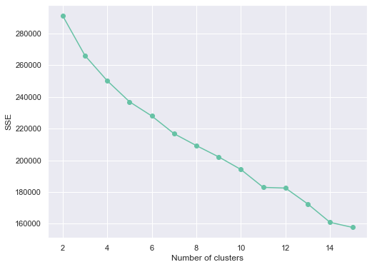

```python
from sklearn.metrics import calinski_harabasz_score
distortions_euclidean = []
ch_score_euclidean = []
n_clusters_max = 15
clusters_list = range(2,n_clusters_max+1)
for n_clusters in clusters_list:
    k_means = KMeans(n_clusters=n_clusters, random_state=41)
    k_means.fit(X_norm)
    distortions_euclidean.append(k_means.inertia_)
    ch_score_euclidean.append(calinski_harabasz_score(X_norm, k_means.labels_))
plt.figure(figsize=(8,6))
fig = plt.plot(clusters_list, distortions_euclidean, marker='o')
plt.xlabel('Number of clusters')
plt.ylabel('SSE')
plt.show()
```

En el gráfico podemos ver la evolución del error cuadrático medio conforme aumentamos el número de clusters entre los que dividimos los datos. Esta evolución nos puede permitir seleccionar un número óptimo de clusters entre los que dividir las muetras utilizando el método *elbow*. En este caso, se nos haría complicado elegir un número concreto utilizando este método, pues no hay un claro punto de inflexión hasta el cual baje mucho el SSE y a partir del cual esta mejora sea claramente más baja, sino que éste disminuye en forma aproximadamente recta.

Representamos también el índice Calinski-Harabasz como alternativa al SSE.

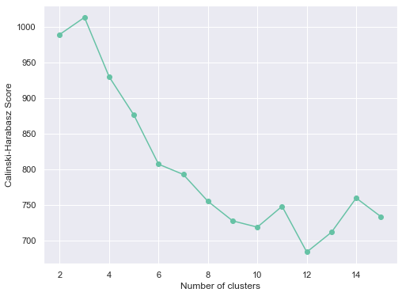

```python
plt.figure(figsize=(8,6))
fig = plt.plot(clusters_list, ch_score_euclidean, marker='o')
plt.xlabel('Number of clusters')
plt.ylabel('Calinski-Harabasz Score')
plt.show()
```

Bajo el criterio de este índice, elegiríamos como 3 el número óptimo de clusters, pues es el que maximiza el valor del índice.